# 531 Midterm Project

The time series dataset we analyze here is the monthly information of the Brazilian GDP (Gross Domestic Product) series which starts from January of 1980 until December of 1997 containing 216 months. We will get a basic idea of how this series data extend along the time horizon by checking the trend, cycles (if any) using tools like specturm analysis, local linear regression firstly. In a futher step, we try to fit a model for this data and get some insight of how that model means in reality by looking at the model we build. Predition will always be the thing we are interested in based on the model and the dataset we get which is also a work we will touch on at the last of my project.

## Data Analysis

```r
data=read.csv(file="http://www2.stat.duke.edu/~mw/data-sets/ts_data/brazil_econ", skip=14, sep="",header=FALSE)
```

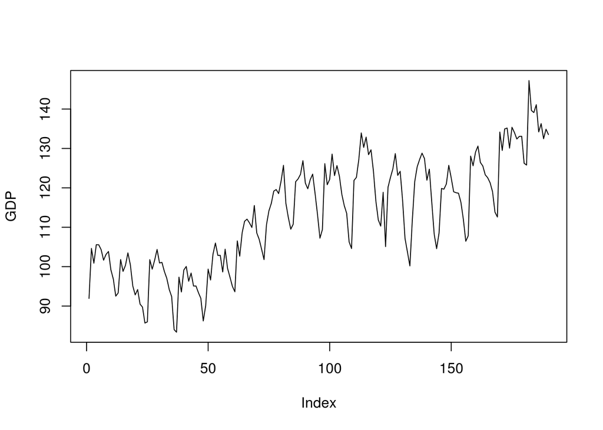

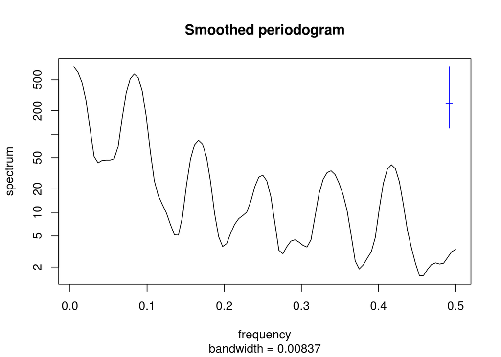

Decompose the original data in a further step, we seperate the chaotic line into long term trend plus cycle plus colored noise here.

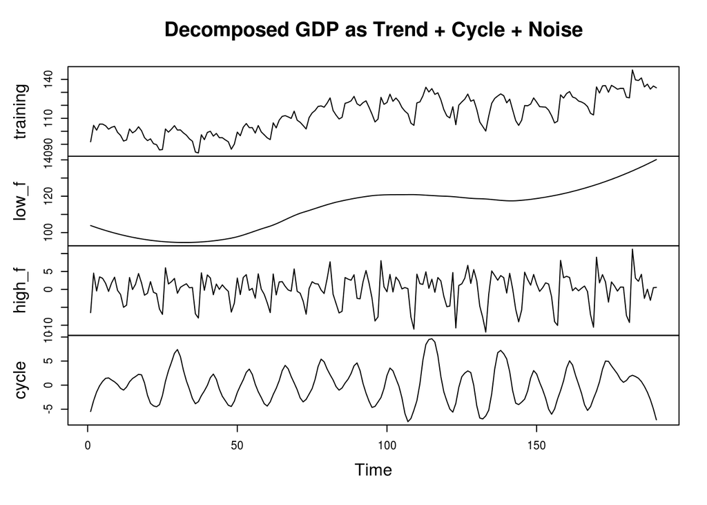

```r
low_f= ts(loess(training~seq(1:190),span=0.5)$fitted)
high_f=ts(training-loess(training~seq(1:190),span=0.1)$fitted)
cycle=training-low_f-high_f
plot(ts.union(training,low_f,high_f,cycle),main="Decomposed GDP as Trend + Cycle + Noise")
```

We will conclude that the Brazilian economy kept blooming in the years 1980-1997 in general. While the econony has its own pattern in inspite of the upgoing trend considering GDP as an indicator of the well-being of overall economy. Within each year, it has its prosperity basically at May, June and July and stagnancy at the beginning and the end of a year. On the basis of that, there is some highy frequency noise of the behaviour of the econmy which we can develop ARMA model for that part if we want to know the detail. (As for the detailed model to clarify clearly how the parttern is, we will discuss next).

## Model Selection

#### SARMA Model

Now we are thinking of developing a model to figure out in detail how the underlying system goin on beneath the obeservations. The first model comes to mind when looking at the seasonal pattern is the SARIMA$(p,d,q){\times}(P,D,Q)_{12}$ (Seasonal AutoRegressive Moving Average Model). The ACF plot below intensify our analysis that period effect should 12 months.

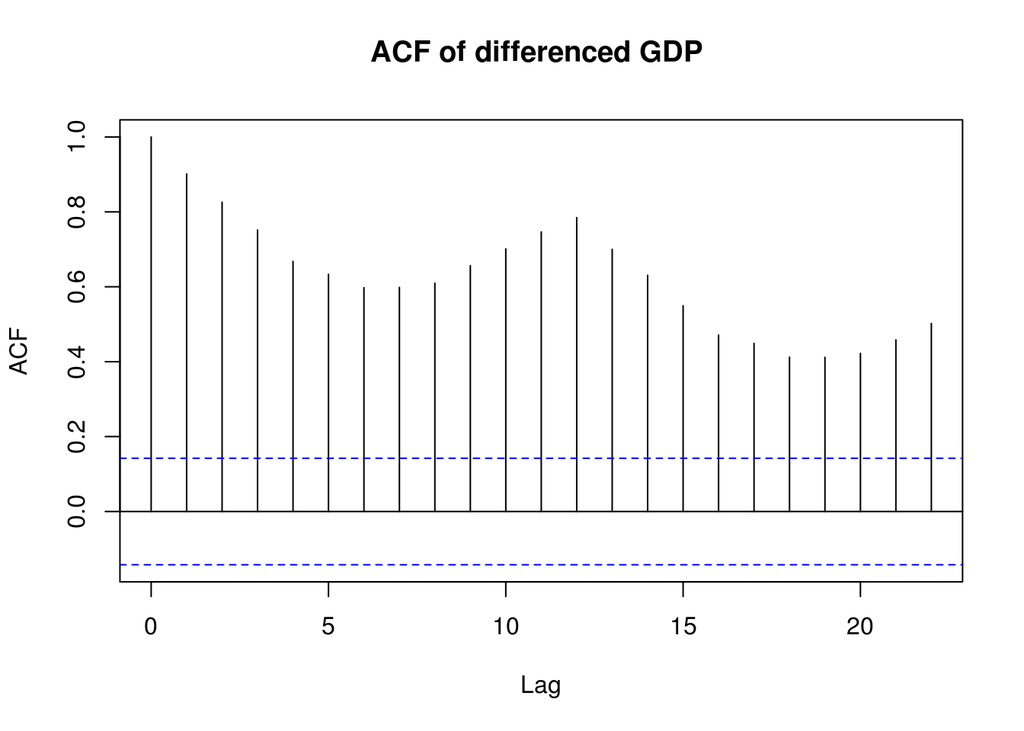

We first difference the data with lag of twelve and get the new series of $Y_{n}=(1-B^{12})X_{n}$

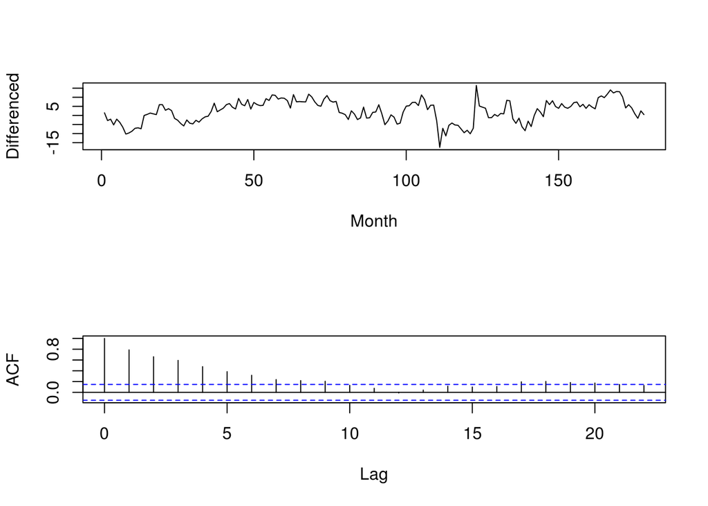

From the plot we believe that this new seires $Y_{n}$ is generally a weak stationary time series with equal variance while the ACF of this ${Y_n}$ show the correlaiton along time axis. All these properties motivates us to build a ARMA model for the ${Y_n}$ data. So we use the AIC model selection criteria to choose the best model for ${Y_n}$.

|  | MA0 | MA1 | MA2 | MA3 | MA4 | MA5 |
| --- | --- | --- | --- | --- | --- | --- |
| AR0 | 1146.59 | 1044.58 | 1022.24 | 1000.05 | 986.77 | 978.52 |
| AR1 | 977.36 | 976.68 | 978.01 | 976.23 | 977.29 | 978.72 |
| AR2 | 977.30 | 978.47 | 972.00 | 973.96 | 977.80 | 974.16 |
| AR3 | 976.64 | 977.41 | 969.59 | 966.58 | 967.19 | 974.70 |
| AR4 | 976.48 | 978.35 | 971.52 | 961.14 | 962.98 | 964.81 |

The priciple for the AIC selection is to choose the model with the least AIC while keeping the model as simple and compact as possible without losing the effeciveness. As for this specific case, AR(1) and ARMA(1,1) are all good choice. We need to actually build the model and check the fitness of the model to select a better (in the sense of interpretability) model. We start from the less complicated one AR(1) and if it fits well there will be no necessarity to try ARMA(1,1). So we model we first try is $Y_n = {\phi}Y_{n-1}+\epsilon_n$. We plug in $X_n$ in to $Y_n$ and derive the model of $X_n$ to be a SARMA $(1,0,0)\times(0,1,0)_12$ $(1-{\phi}X_{n})((1-B^{12})X_n-\mu)=\epsilon_n$

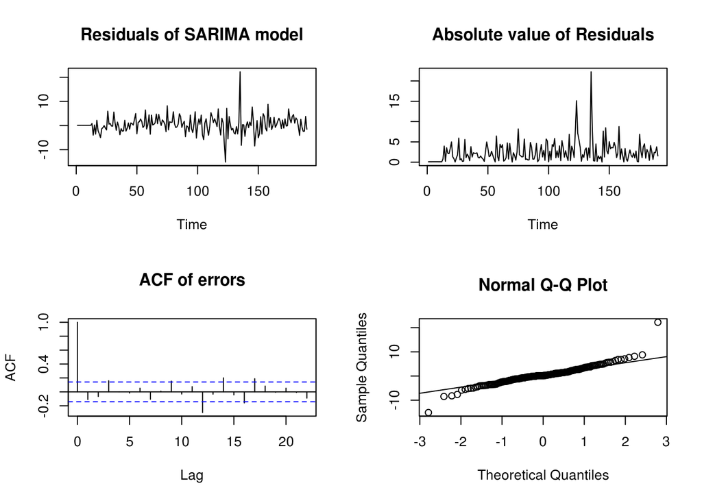

```r
par(mfrow=c(2,2))
plot(resid(sarma),ylab=" ",main="Residuals of SARIMA model")
plot(abs(sarma$residuals),ylab=" ",main="Absolute value of Residuals")
acf(resid(sarma),main="ACF of errors")
qqnorm(sarma$residuals)
qqline(sarma$residuals)
```

```r
Box.test(sarma$residuals)
```

```
##
##  Box-Pierce test
##
## data:  sarma$residuals
## X-squared = 2.2897, df = 1, p-value = 0.1302
```

Since this model is quite satisfactorying, we now show the coefficients of the model and the plot of how it fitted inside the training set.

```
##
## Call:
## arima(x = training, order = c(1, 0, 0), seasonal = list(order = c(0, 1, 0),
##     period = 12))
##
## Coefficients:
##          ar1
##       0.8108
## s.e.  0.0428
##
## sigma^2 estimated as 13.86:  log likelihood = -487.1,  aic = 978.2
```

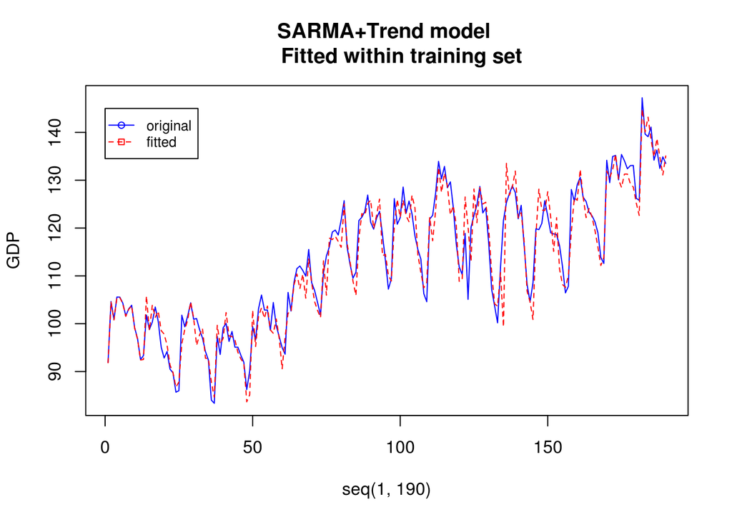

#### Deterministic Trend + ARMA Error Model

In addition to the SARMA model, there is another option that we can fit a model of Linear trend + sinusoidal function +ARMA Error. $X_n= {\beta} n + A sin({\pi}X_n/6 ) + B cos({\pi}X_n/6 ) + ARMA\ Error$ Note that $X_n$ denote the obervation at time point n Here shows the deterministic trend estimated by OLS Method to get the parameter as well as the residuals for further ARMA model.

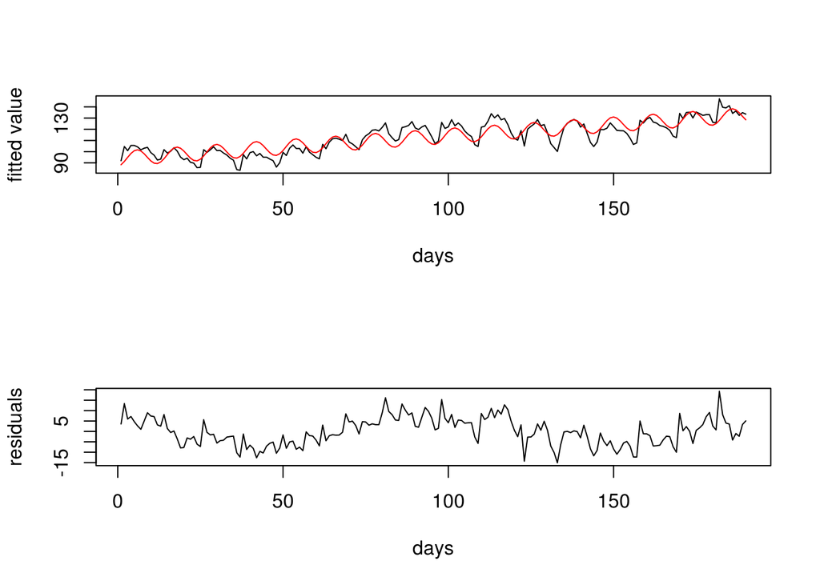

```r
m2
```

```
##
## Call:
## lm(formula = training ~ sin(2 * pi * x/12) + cos(2 * pi * x/(12)) +
##     x)
##
## Coefficients:
##          (Intercept)    sin(2 * pi * x/12)  cos(2 * pi * x/(12))
##              93.6758                0.6438               -6.7460
##                    x
##               0.2038
```

We check the AIC table for the redisuals ARMA(p,q) to select the p and q and it shows that p=2 and q=2 gives the least AIC without getting the model too large. As the reasoning we give before,we will try this model first and accept that if it behaves well. Else, we can enlarge the model to include more parameters if the first picked one fails. Anyway we try the ARMA(2,2) at the first hand.

|  | MA0 | MA1 | MA2 | MA3 | MA4 | MA5 |
| --- | --- | --- | --- | --- | --- | --- |
| AR0 | 1259.67 | 1179.11 | 1170.92 | 1141.18 | 1142.61 | 1140.30 |
| AR1 | 1141.16 | 1132.53 | 1128.47 | 1142.03 | 1126.12 | 1120.39 |
| AR2 | 1137.42 | 1128.97 | 1123.08 | 1124.85 | 1123.24 | 1122.27 |
| AR3 | 1133.92 | 1126.29 | 1124.66 | 1111.72 | 1118.27 | 1117.42 |
| AR4 | 1135.92 | 1128.27 | 1124.74 | 1107.06 | 1115.76 | 1117.31 |

The ACF plot of the residuals after fitting ARMA(2,2) does not seem so good, the outstanding value at lag 12 indicates that we should extend the model to ARMA(12,2) to incorporate the autocorrelation after 12 months.

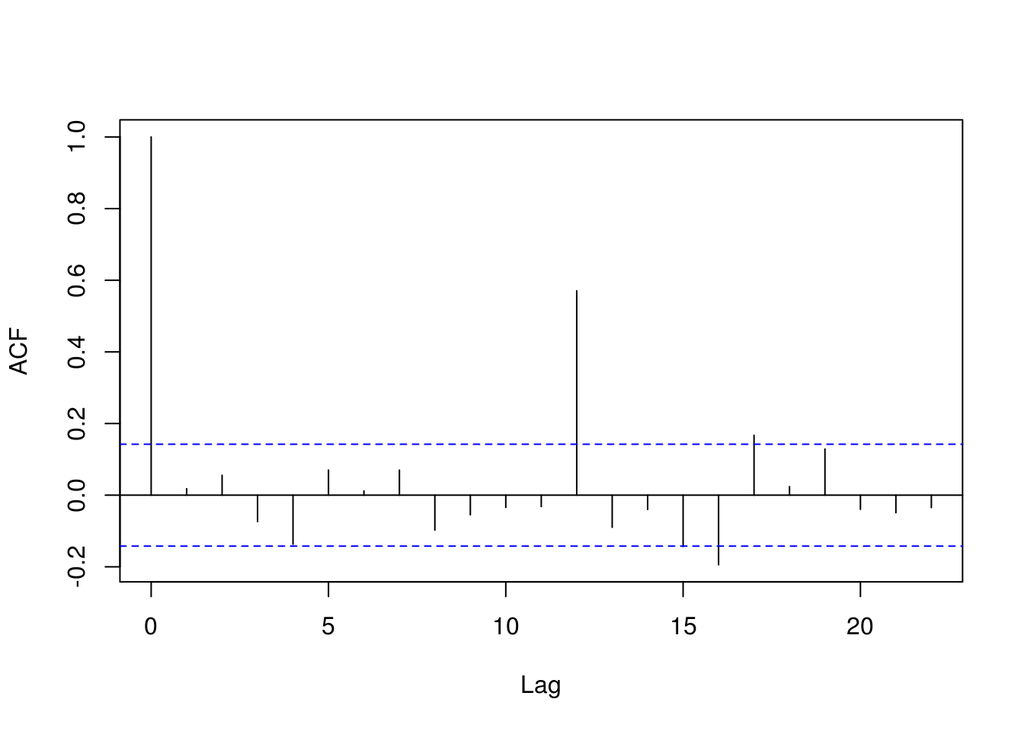

Here show the detailed examination of the residuals after fitting ARMA(12,2) model. We have not seen obvious evidence to object the white noise assumption by those four results. So that should be a pretty good model

```
##
## Call:
## arima(x = m2$residuals, order = c(12, 0, 2))
##
## Coefficients:
##           ar1     ar2     ar3     ar4     ar5     ar6     ar7      ar8
##       -0.0870  0.1387  0.2552  0.0011  0.1669  0.0526  0.0763  -0.0740
## s.e.   0.1035  0.0764  0.0698  0.0668  0.0663  0.0694  0.0683   0.0661
##           ar9     ar10     ar11    ar12     ma1     ma2  intercept
##       -0.0125  -0.1442  -0.0797  0.5436  0.8276  0.3262     1.3447
## s.e.   0.0685   0.0675   0.0660  0.0661  0.1239  0.0921     2.8838
##
## sigma^2 estimated as 11.93:  log likelihood = -508.82,  aic = 1049.63
```

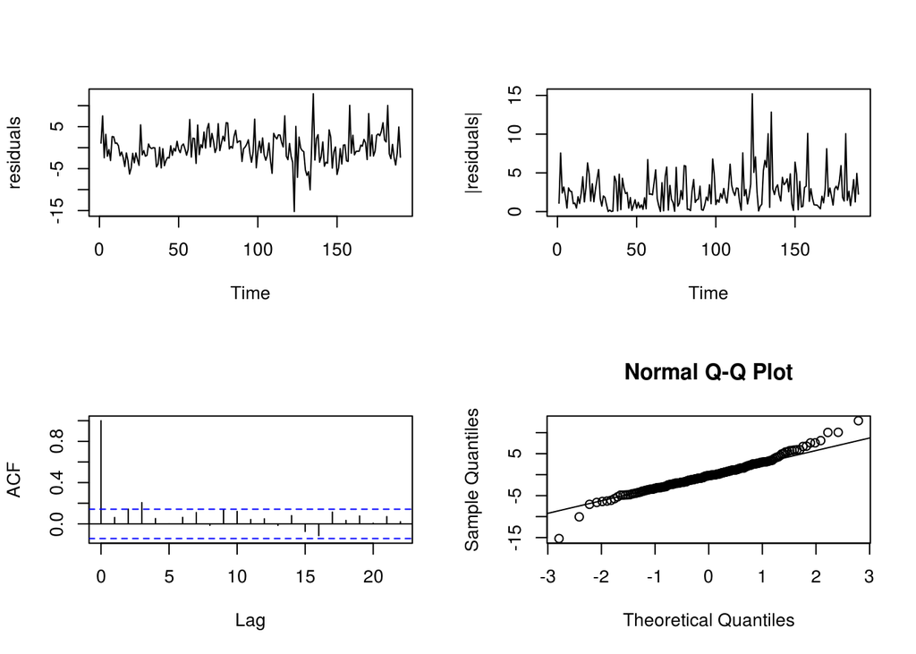

The second model we conclude here is $X_n=93.67 + 0.64sin({\pi}X_n /6)-6.75cos({\pi}X_n /6) + 0.204X_n + E_n$ where $E_n$ is a ARMA(12,2) proces with coefficients shown below

```r
arma1
```

```
##
## Call:
## arima(x = m2$residuals, order = c(12, 0, 2), fixed = c(0, 0, NA, 0, NA, 0, 0,
##     0, 0, NA, 0, NA, NA, NA, NA))
##
## Coefficients:
##       ar1  ar2     ar3  ar4     ar5  ar6  ar7  ar8  ar9     ar10  ar11
##         0    0  0.2270    0  0.1773    0    0    0    0  -0.1452     0
## s.e.    0    0  0.0585    0  0.0557    0    0    0    0   0.0532     0
##         ar12     ma1     ma2  intercept
##       0.5931  0.6728  0.3372     1.5822
## s.e.  0.0553  0.0722  0.0659     2.9183
##
## sigma^2 estimated as 12.76:  log likelihood = -515.19,  aic = 1046.37
```

## Forecasting

For each of the prediction graphs, the Blak line is the real GDP data of the Brazil Country for the following 25 months and the red line is forecasting we made from the corresponding model with the confidence interval marked by the dashed lines.

#### Prediction from SARMA model

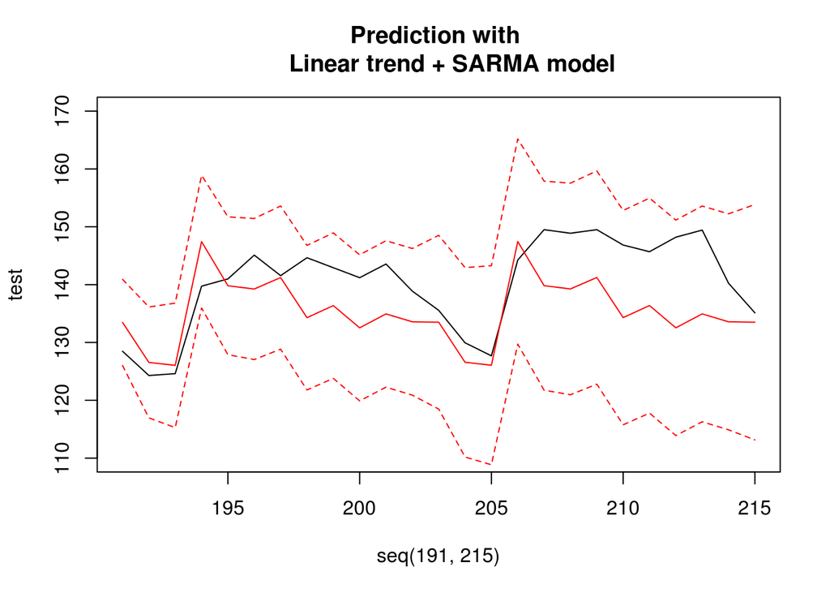

#### Prediction from Sinoidal Trend + ARMA Error Model

[figure not shown]

## Reference

[1]“http://www2.stat.duke.edu/~mw/data-sets/ts_data/brazil_econ” for dataset

[2]Robert H.Shumway, David S.Stoffer “Time Series Analysis and Its Application with R Example”(Third Edition)

[3]http://ionides.github.io/531w16